# chap6_summarized_data_distributions

J.H AHN

2022 1 10

### 6.1 Making a basic histogram

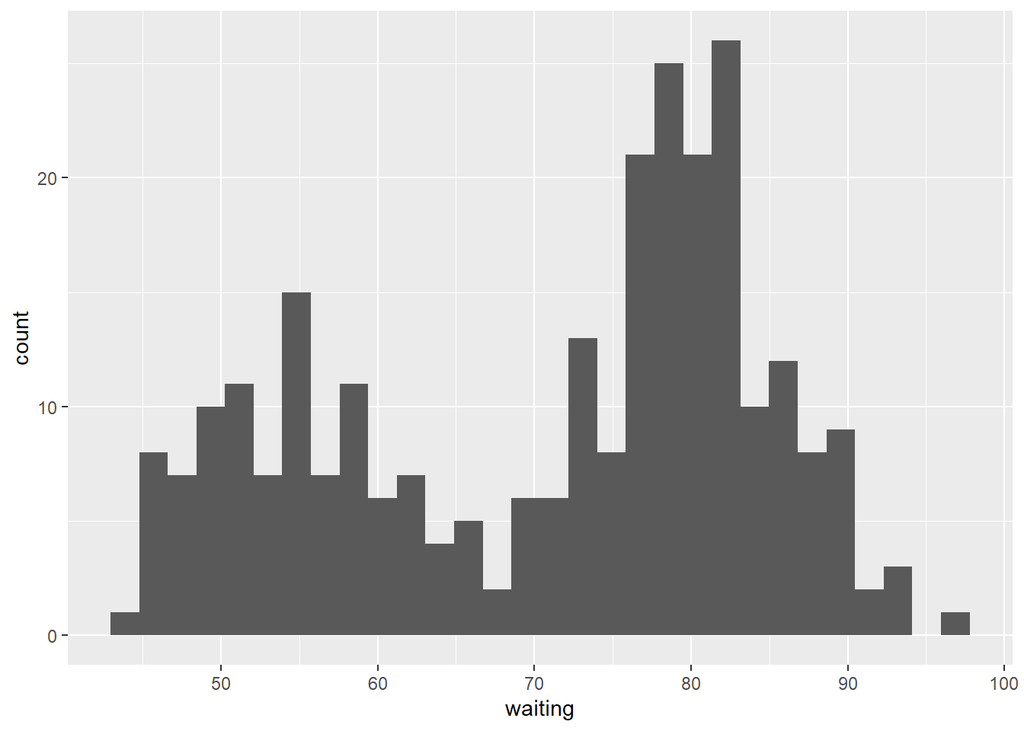

```r
faithful %>%
  ggplot(aes(x = waiting)) +
  geom_histogram()
```

만약 빠르게 데이터 프레임에 없는 데이터를 보려면 NULL을 입력하고 `ggplot()`에서 벡터 값을 불러오는 방식으로 쓸 수도 있다.

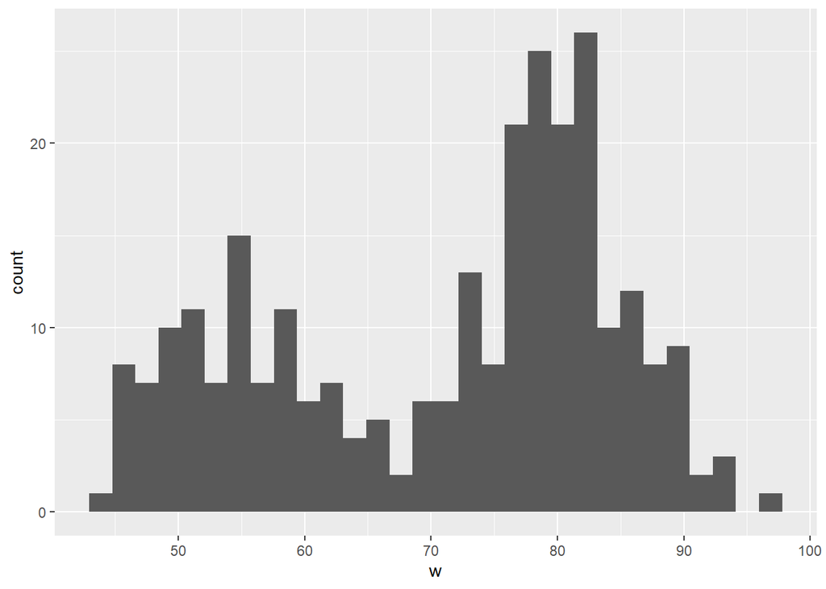

```r
# Store the values in a simple vector

w <- faithful$waiting

ggplot(NULL, aes(x = w)) +
  geom_histogram()
```

default로 데이터는 30 bins로 구성되나 필요에 따라 bin의 수량이나 폭은 변경할 수 있다.  
아래 예시에서 `diff()`와 `range()`를 조합해서 x축의 범위를 15개로 나눈 후 그리는 방법을 보여준다.  
’diff()`는 앞의 값과 다음 값의 차이를 계산해 주는 함수이고,`range()`는 주어진 벡터의 최대와 최소값을 반환하는 함수이다. 즉`range()`함수로 x축의 최대값과 최소값을 반환하여`diff()`함수로 두 값을 차이를 계산 후 15등분하는 것이다.

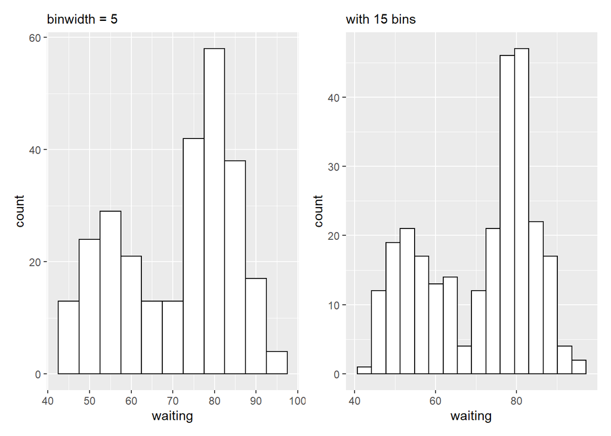

```r
# Set the width of each bin to 5
fig_6021 <-
  faithful %>%
  ggplot(aes(x = waiting)) +
  geom_histogram(binwidth = 5, fill = "#FFFFFF", color = "#000000") +
  labs(subtitle = "binwidth = 5")

# Divide the x range into 15 bins
binsize = diff(range(faithful$waiting)) / 15

fig_6022 <-
  faithful %>%
  ggplot(aes(x = waiting)) +
  geom_histogram(binwidth = binsize, fill = "#FFFFFF", color = "#000000") +
  labs(subtitle = "with 15 bins")


fig_6021 + fig_6022
```

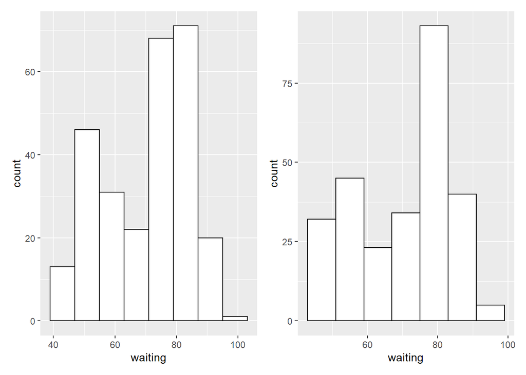

```r
h <-
  faithful %>%
  ggplot(aes(x = waiting))

fig_6031 <-
  h + geom_histogram(binwidth = 8, fill = "#FFFFFF", color = "#000000", boundary = 31)

fig_6032 <-
  h + geom_histogram(binwidth = 8, fill = "#FFFFFF", color = "#000000", boundary = 35)

fig_6031 + fig_6032
```

### 6.2 Making multiple histogram from grouped data

```r
library(MASS)
birthwt
```

```
##     low age lwt race smoke ptl ht ui ftv  bwt
## 85    0  19 182    2     0   0  0  1   0 2523
## 86    0  33 155    3     0   0  0  0   3 2551
## 87    0  20 105    1     1   0  0  0   1 2557
## 88    0  21 108    1     1   0  0  1   2 2594
## 89    0  18 107    1     1   0  0  1   0 2600
## 91    0  21 124    3     0   0  0  0   0 2622
## 92    0  22 118    1     0   0  0  0   1 2637
## 93    0  17 103    3     0   0  0  0   1 2637
## 94    0  29 123    1     1   0  0  0   1 2663
## 95    0  26 113    1     1   0  0  0   0 2665
## 96    0  19  95    3     0   0  0  0   0 2722
## 97    0  19 150    3     0   0  0  0   1 2733
## 98    0  22  95    3     0   0  1  0   0 2751
## 99    0  30 107    3     0   1  0  1   2 2750
```

[output cut: 175 more lines]

`facet_wrap()`으로 각 그룹의 historam을 만들 수 있다.  
아래 예시는 그룹으로 나눈 후 label을 붙이는 방법을 보여준다.  
`labeller = as_labeller(c(...))`를 이용하여 label을 붙이는 것이 가능하고, 처음부터 데이터의 0과 1값을 No Smoke와 Smoke로 값을 바꾼 후 histogram을 그리는 것도 가능하다.

이런 histogram을 그리기 위해서는 facet하는 열이 categorical variable이어야 한다.

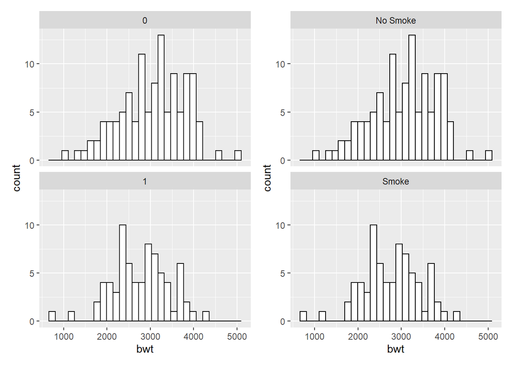

```r
fig6041 <-
  birthwt %>%
  ggplot(aes(x = bwt)) +
  geom_histogram(fill = "#FFFFFF", color = "#000000") +
  facet_wrap(~ smoke, ncol = 1)

fig6042 <-
  birthwt %>%
  ggplot(aes(x = bwt)) +
  geom_histogram(fill = "#FFFFFF", color = "#000000") +
  facet_wrap(~ smoke, ncol = 1,
             labeller = as_labeller(c('0' = "No Smoke", '1' = "Smoke")))

fig6041 + fig6042
```

facet을 사용할 때 각 facet은 같은 y scaling을 가지기 때문에 그룹의 분포를 비교하는데 어려움이 있을 수 있다.  
예를 들어 race로 birth weight을 facet하는 경우를 보자.

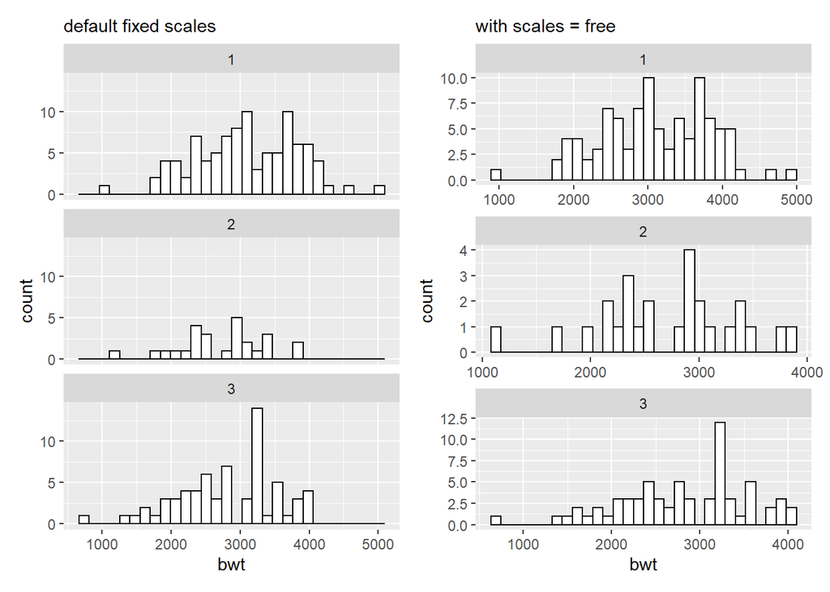

```r
fig6051 <-
  birthwt %>%
  ggplot(aes(x = bwt)) +
  geom_histogram(fill = "#FFFFFF", color = "#000000") +
  facet_wrap(~ race, ncol = 1) +
  labs(subtitle = "default fixed scales")

fig6052 <-
  birthwt %>%
  ggplot(aes(x = bwt)) +
  geom_histogram(fill = "#FFFFFF", color = "#000000") +
  facet_wrap(~ race, ncol = 1, scales = "free") +
  labs(subtitle = "with scales = free")

fig6051 + fig6052
```

그룹핑한 변수를 맵핑하는 다른 방법으로 `fill`을 이용하는 방법이 있다.  
그룹핑하는 변수는 factor나 character 벡터이어야 한다.  
그래서 smoke열을 factor로 변환 후 histogram을 그리면 된다.

이런 식으로 그릴 때 `position`을 “identity”로 해주어야 한다.  
“identity”로 설정하지 않으면 stacking하기 때문에 분포를 파악하기 어렵기 때문이다.

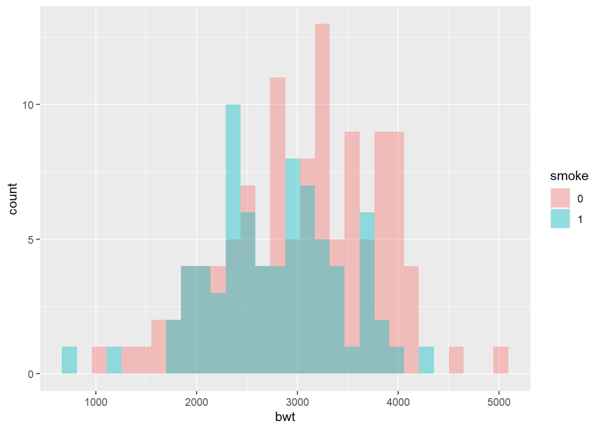

```r
birthwt %>%
  mutate(smoke = factor(smoke)) %>%
  ggplot(aes(x = bwt, fill = smoke)) +
  geom_histogram(position = "identity", alpha = 0.4)
```

### 6.3 Making a density curve

`geom_density()`는 연속형 변수인 x의 분호를 그릴 때 사용된다.

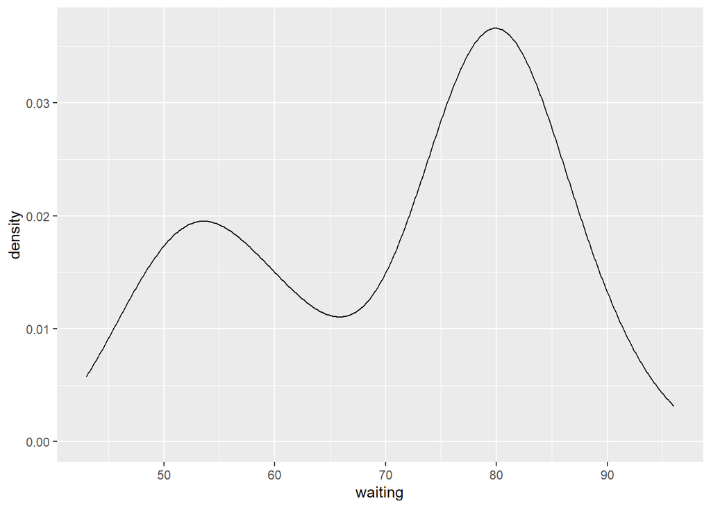

```r
faithful %>%
  ggplot(aes(x = waiting)) +
  geom_density()
```

`geom_density()`도 `geom_histogram()`과 동일하게 NULL값을 쓰고 벡터를 넣어 그리는 것이 가능하다.

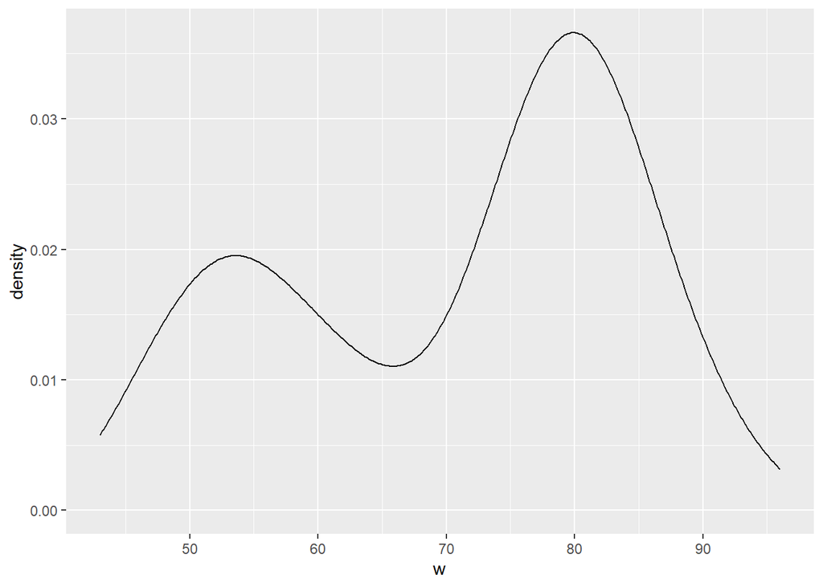

```r
w <- faithful$waiting

ggplot(NULL, aes(x = w)) + geom_density()
```

데이터 분포를 예측하는데 kernel density curve를 사용하는데 smoothing 정도는 *kernel bandwidth*에 따라 결정된다.  
이 값이 클 수록 더 평활해지고, 작을 수록 변동을 잘 반영한다.

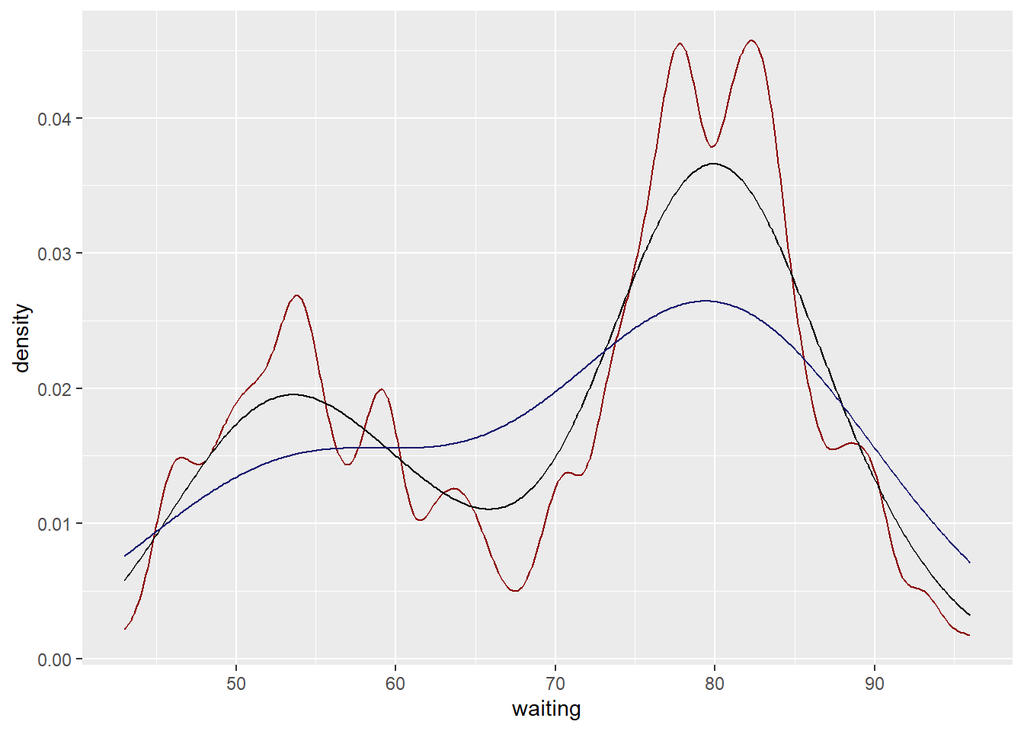

```r
faithful %>%
  ggplot(aes(x = waiting)) +
  geom_line(stat = "density", adjust = 0.25, color = "#8B0000") +
  geom_line(stat = "density") +
  geom_line(stat = "density", adjust = 2, color = "#191970")
```

x축의 값은 모든 데이터를 담을 수 있도록 설정되는데 이 때문에 양 끝의 값이 잘리는 경우가 발생하기도 한다.  
curve를 더 많이 보일 수 있도록 x축의 limits을 설정한다.

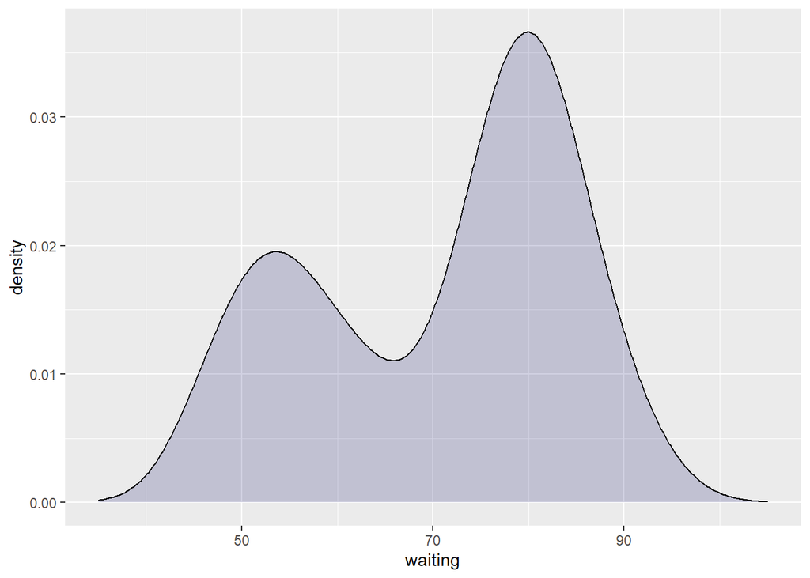

```r
faithful %>%
  ggplot(aes(x = waiting)) +
  geom_density(fill = "#191970", alpha = 0.2) +
  xlim(35, 105)
```

이론값과 실제 관측값을 비교할 때 density curve와 historam을 겹칠 수 있다.  
density curve의 y값은 작기 때문에 histogram에 변형을 가하지 않으면 보기 어렵다.  
이러한 문제점을 해결하기 위해서 histogram을 density curve에 매칭시킬 수 있도록 scale down 해 주는 것이 필요하다. 이를 위해 `ggplot(aes(...))`에서 **y = ..density..**을 넣어주어야 한다. 이렇게 그릴 때는 `geom_histogram()`을 먼저 그리고, `geom_density()`를 레이어링한다.

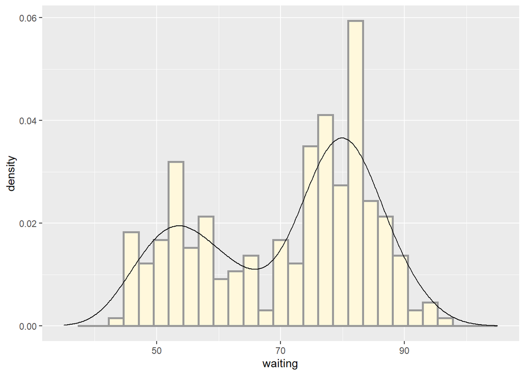

```r
faithful %>%
  ggplot(aes(x = waiting, y = ..density..)) +
  geom_histogram(fill = "#FFF8DC", color = "gray60", size = 1) +
  geom_density() +
  xlim(35, 105)
```

### 6.4 Making multiple density curves from grouped data

흡연여부가 bwt(birth weight in grams)에 미치는 영향을 아래와 같이 나타낼 수 있다.  
이를 위해서는 histogram과 마찬가지로 smoke를 factor로 바꿔주는 것이 필요하다.

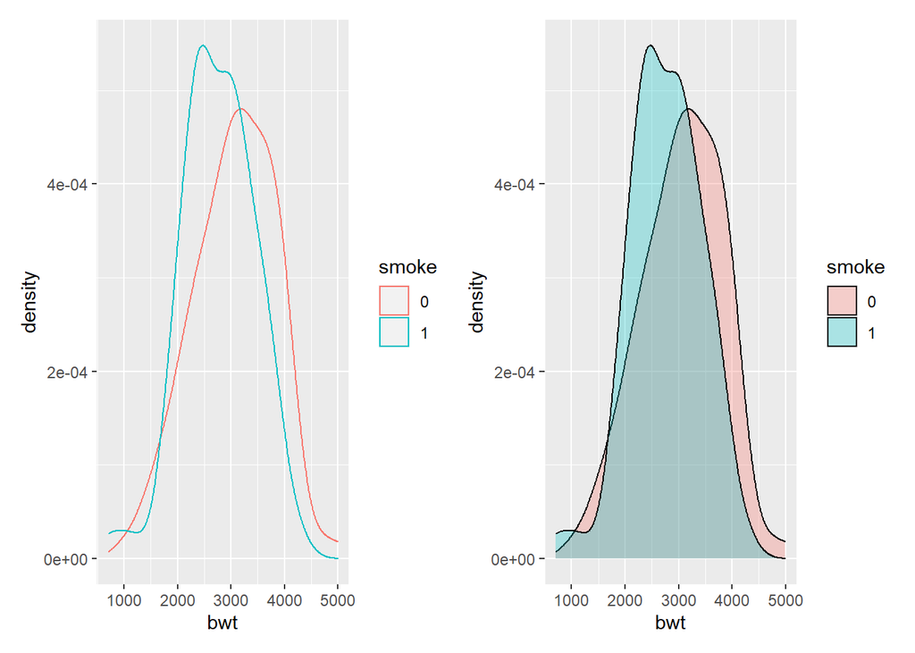

```r
fig_6111 <-
  birthwt %>%
  mutate(smoke = factor(smoke)) %>%
  ggplot(aes(x = bwt, color = smoke)) +
  geom_density()

fig_6112 <-
  birthwt %>%
  mutate(smoke = factor(smoke)) %>%
  ggplot(aes(x = bwt, fill = smoke)) +
  geom_density(alpha = 0.3)

fig_6111 + fig_6112
```

다른 방법으로는 facet을 이용하여 일렬(수직 혹은 수평방향)로 나열하여 보여주는 것이다.  
수직방향으로 나열하는 것이 두 분포를 비교하는데 더 편하다.

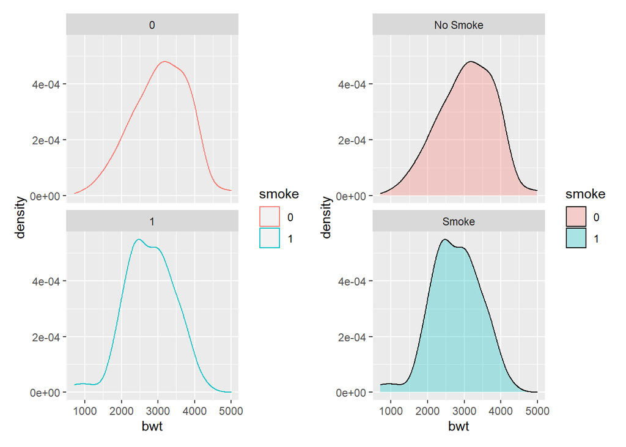

```r
fig_6121 <-
  birthwt %>%
  mutate(smoke = factor(smoke)) %>%
  ggplot(aes(x = bwt, color = smoke)) +
  geom_density() +
  facet_wrap(~ smoke, ncol = 1)

fig_6122 <-
  birthwt %>%
  mutate(smoke = factor(smoke)) %>%
  ggplot(aes(x = bwt, fill = smoke)) +
  geom_density(alpha = 0.3) +
  facet_wrap(~ smoke, ncol = 1,
             labeller = as_labeller(c('0' = "No Smoke", '1' = "Smoke")))

fig_6121 + fig_6122
```

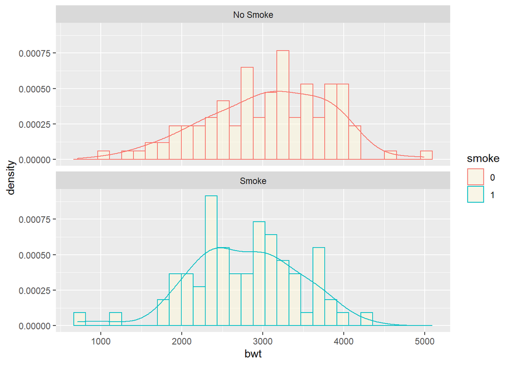

```r
birthwt %>%
  mutate(smoke = factor(smoke)) %>%
  ggplot(aes(x = bwt, y = ..density.., color = smoke)) +
  geom_histogram(fill = "#FFF8DC", alpha = 0.5) +
  geom_density() +
  facet_wrap(~ smoke, ncol = 1,
             labeller = as_labeller(c('0' = "No Smoke", '1' = "Smoke")))
```

### 6.5 Making a frequency polygon

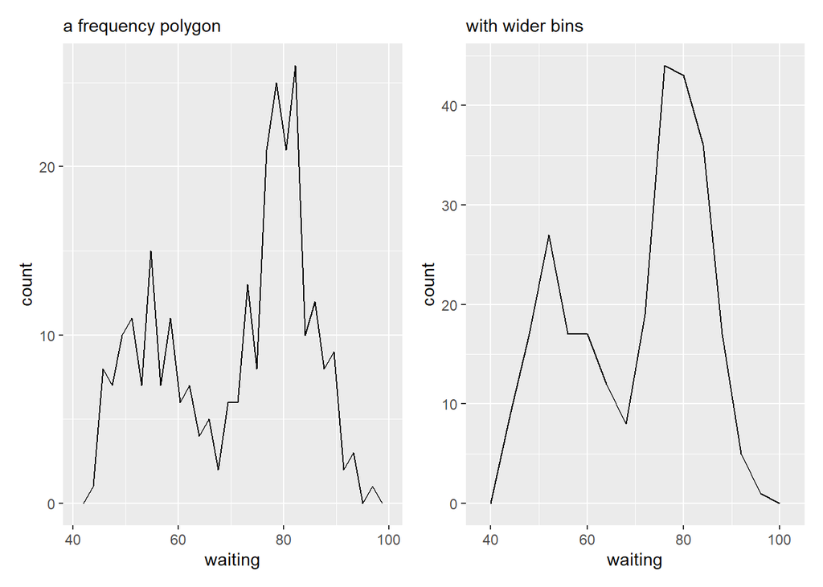

```r
fig_6141 <-
  faithful %>%
  ggplot(aes(x = waiting)) +
  geom_freqpoly() +
  labs(subtitle = "a frequency polygon")

fig_6142 <-
  faithful %>%
  ggplot(aes(x = waiting)) +
  geom_freqpoly(binwidth = 4) +
  labs(subtitle = "with wider bins")

fig_6141 + fig_6142
```

### 6.6 Making a basic box plot

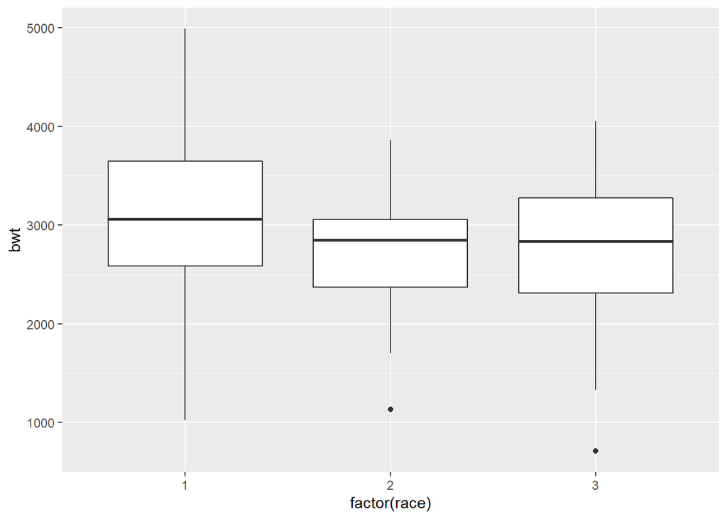

```r
birthwt %>%
  ggplot(aes(x = factor(race), y = bwt)) +
  geom_boxplot()
```

위에서는 race를 1,2,3의 값으로 되어 있어 `ggplot()`은 어느 변수를 grouping 할 수 있는지를 모른다.  
따라서 적절하게 그룹핑하기 위해서는 `ggplot()`안에 `factor()`를 써서 race를 factor로 변경해 주었다.

box plot에서 outliner는 size = 2, shape = 16이 default값으로 설정되어 있다.

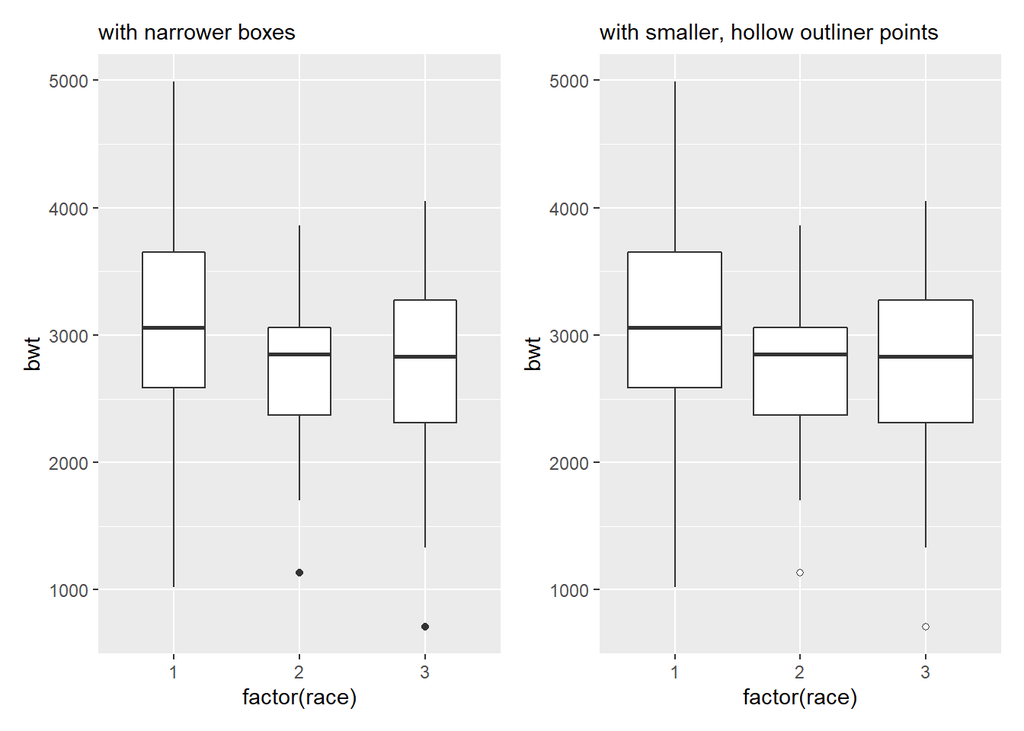

```r
fig_6171 <-
  birthwt %>%
  ggplot(aes(x = factor(race), y = bwt)) +
  geom_boxplot(width = 0.5) +
  labs(subtitle = "with narrower boxes")

fig_6172 <-
  birthwt %>%
  ggplot(aes(x = factor(race), y = bwt)) +
  geom_boxplot(outlier.size = 1.5, outlier.shape = 21) +
  labs(subtitle = "with smaller, hollow outliner points")

fig_6171 + fig_6172
```

한 그룹만 box plot으로 그릴려면 x에 임의의 값을 주어야 한다. 반면에 `ggplot()`은 box plot을 그리기 위해 어느 x 좌표를 써야 할 지 모르기 때문에 이럴 때는 x = 1로 입력하고 x축의 틱마크와 라벨은 출력되지 않게 한다.

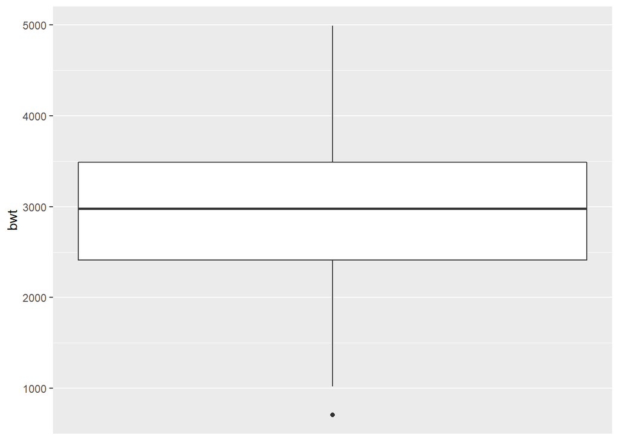

```r
birthwt %>%
  ggplot(aes(x = 1, y = bwt)) +
  geom_boxplot() +
  scale_x_continuous(breaks = NULL) +      # remove x-axis tick marker
  theme(axis.title.x = element_blank())    # remove x-axis label
```

### 6.7 Adding notches to a box plot

```
## notch went outside hinges. Try setting notch=FALSE.
```

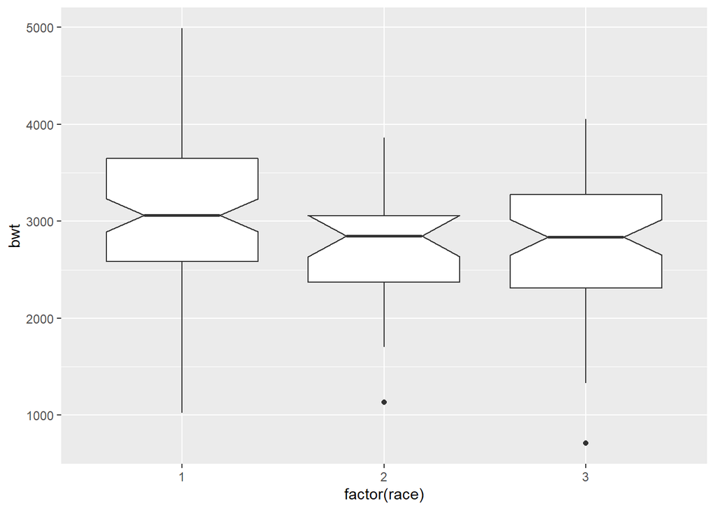

```r
birthwt %>%
  ggplot(aes(x = factor(race), y = bwt)) +
  geom_boxplot(notch = TRUE)
```

### 6.8 Adding means to a box plot

`stat_summary()`를 이용하여 x, y, group별 값을 box plot내에 나타낼 수 있게 함.

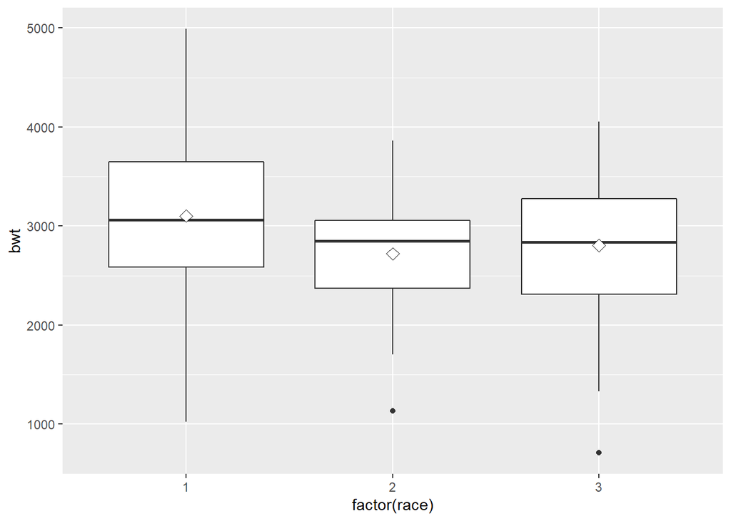

```r
birthwt %>%
  ggplot(aes(x = factor(race), y = bwt)) +
  geom_boxplot() +
  stat_summary(fun.y = "mean", geom = "point", shape = 23, size = 3,
               fill = "#FFFFFF")
```

### 6.9 Making a violin plot

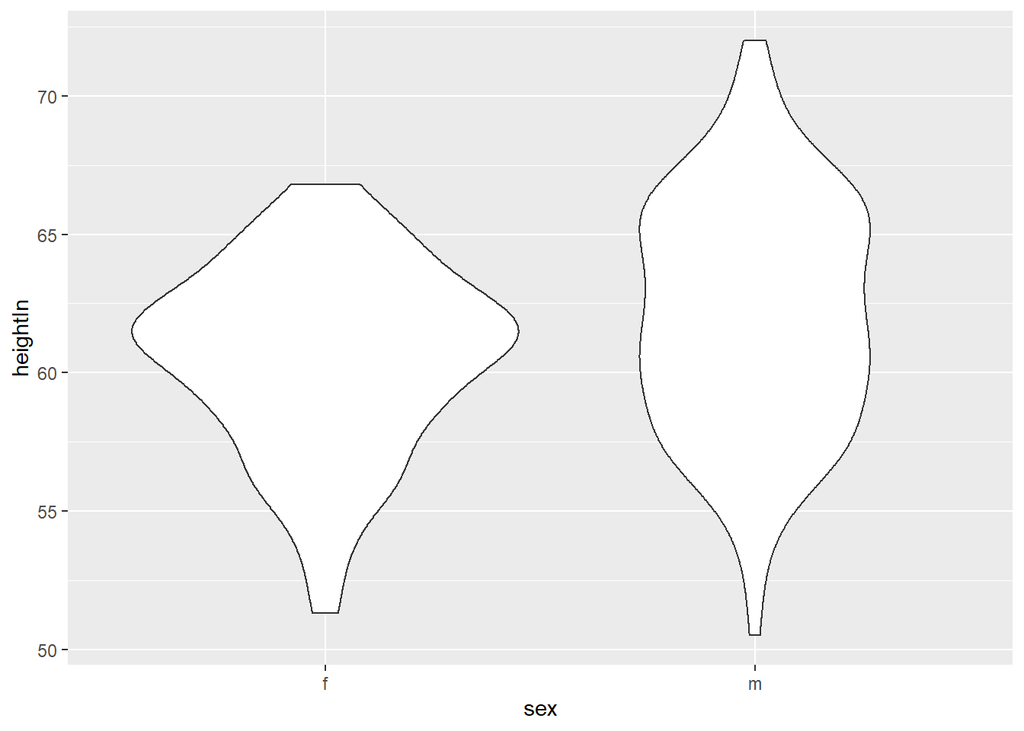

```r
heightweight %>%
  ggplot(aes(x = sex, y = heightIn)) +
  geom_violin()
```

violin plot은 kernel density estimate를 mirror시켜 둔 것이다.  
일반적으로 violin plot 내부에 box plot을 겹쳐서 그리고 중간값을 점으로 표현하고, outliner는 출력하지 않는다.

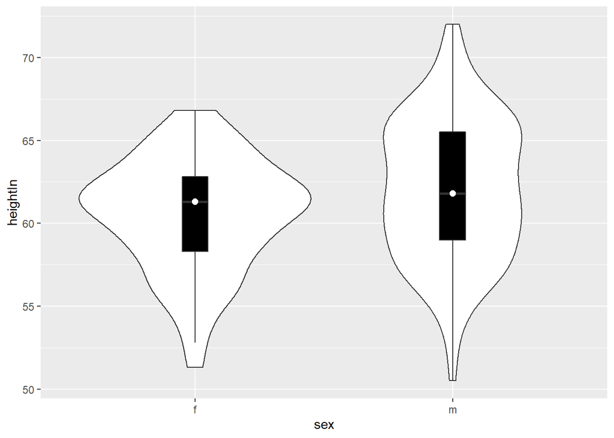

```r
heightweight %>%
  ggplot(aes(x = sex, y = heightIn)) +
  geom_violin() +
  geom_boxplot(width = 0.1, fill = "#000000", outlier.color = NA) +
  stat_summary(fun.y = median, geom = "point", fill = "#FFFFFF",
               shape = 21, size = 2.5)
```

default range는 데이터의 최대값과 최소값으로 정해지는데 평평하게 표현되는 violin plot의 끝부분을 뾰족하게 유지하기 위해서는 `trim = FALSE`로 세팅하면 된다.

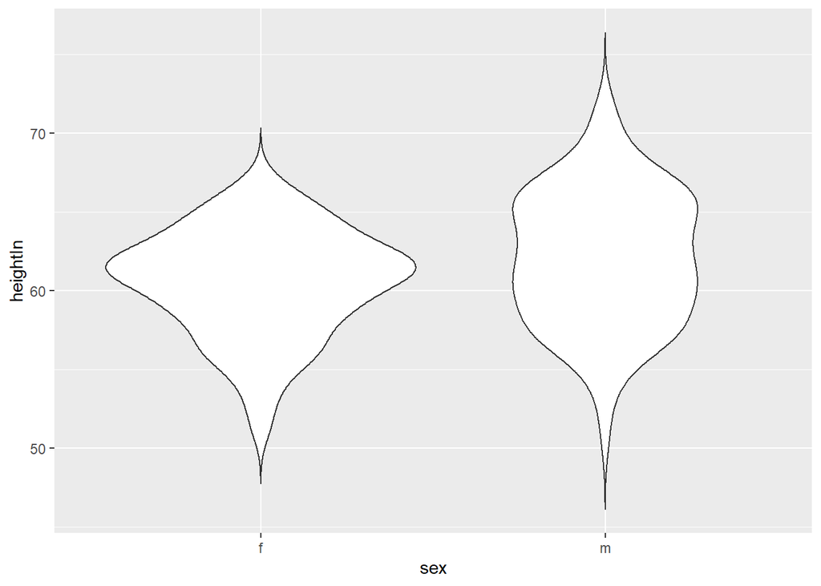

```r
heightweight %>%
  ggplot(aes(x = sex, y = heightIn)) +
  geom_violin(trim = FALSE)
```

violin plot은 각각의 면적이 같게 표현되는데 `scale = "count"`로 설정하면 면적이 각 그룹 관측치의 수에 비례하여 표현된다.

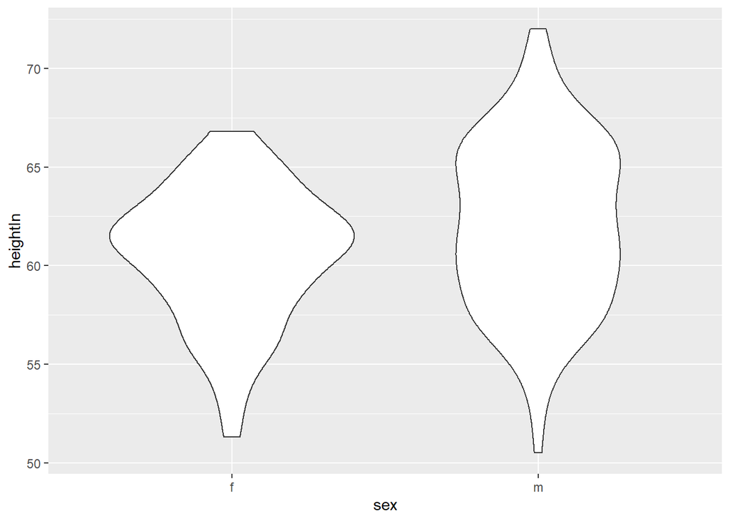

```r
heightweight %>%
  ggplot(aes(x = sex, y = heightIn)) +
  geom_violin(scale = "count")
```

violin plot도 kernel density curve를 사용하는 것이므로 `geom_density()`와 동일하게 adjust값으로 smooth 정도를 조절 가능하다.

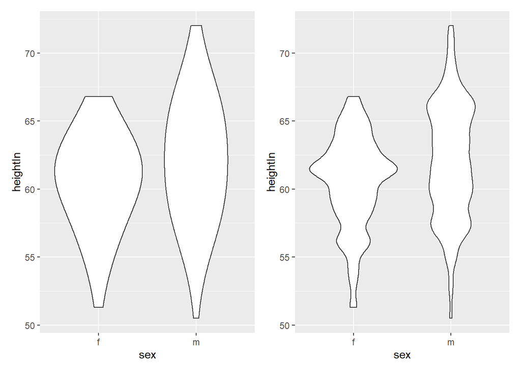

```r
fig_6251 <-
  heightweight %>%
  ggplot(aes(x = sex, y = heightIn)) +
  geom_violin(adjust = 2)

fig_6252 <-
  heightweight %>%
  ggplot(aes(x = sex, y = heightIn)) +
  geom_violin(adjust = 0.5)

fig_6251 + fig_6252
```

### 6.10 Making a dot plot

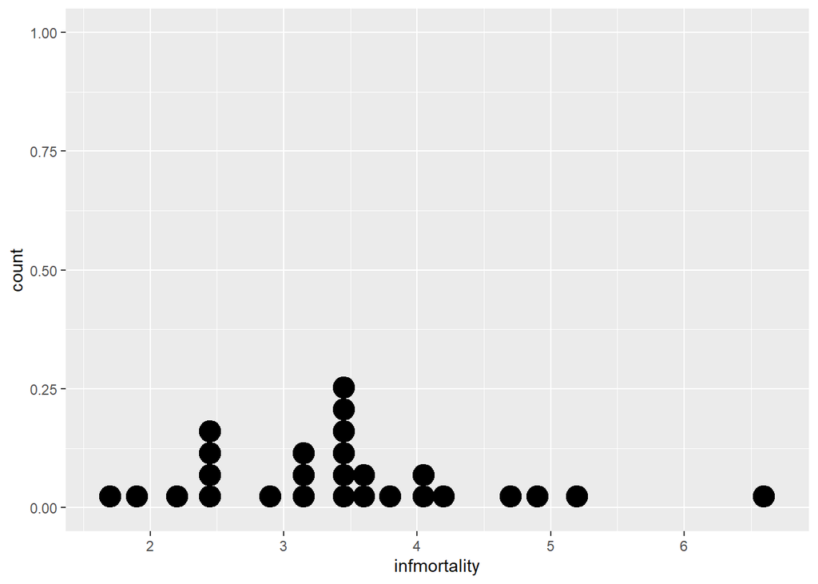

```r
countries2009 <- subset(countries, Year == 2009 & healthexp > 2000)

p <-
  countries2009 %>%
  ggplot(aes(x = infmortality))

p + geom_dotplot()
```

이런 종류의 dot plot을 *Wilkinson dot plot*이라 한다.  
앞서 배운 *Cleveland dot plot*과는 데이터에 따라 bins의 위치가 정해지는 점, 각 bin의 최대 폭이 각 점과 연관성을 가진다는 점에서 다르다. 최대 bin size는 데이터 범위의 1/30(default)로 설정되어 있다.

기본적으로 `geom_dotplot()`은 x축을 따라 y축에 값이 stack 된다.  
dots은 시각적으로는 stack되고 있으나 ggplot2의 기술적 한계 때문에 y축의 tick marks가 의미를 가지지는 못한다.  
따라서 y축의 label은 `scale_y_continuous()`를 사용하여 없애고 `geom_rug()`를 사용하여 그린다.

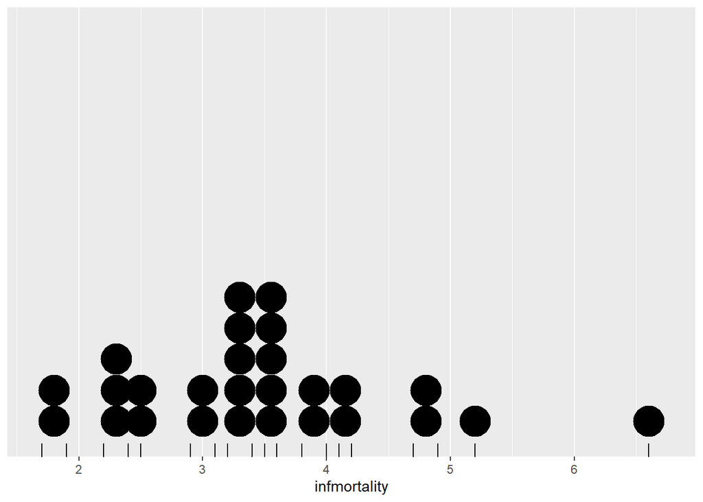

```r
p + geom_dotplot(binwidth = 0.25) +
  geom_rug() +
  scale_y_continuous(breaks = NULL) +
  theme(axis.title.y = element_blank())
```

stack들이 수평방향으로 일정하게 있지 않는데 이건 dotdensity의 알고리즘 때문이다.  
stack의 위치를 histogram처럼 보여지는 일정한 간격으로 정렬하려면 `method = "histodot"`을 사용한다.

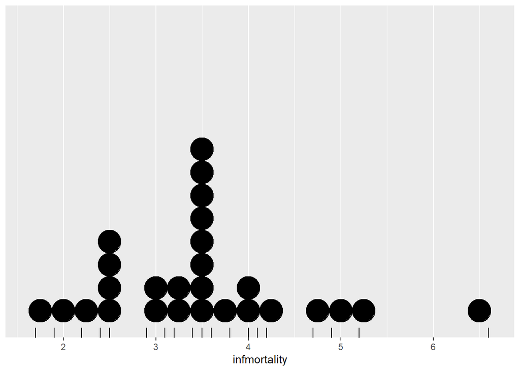

```r
p + geom_dotplot(method = "histodot", binwidth = 0.25) +
  geom_rug() +
  scale_y_continuous(breaks = NULL) +
  theme(axis.title.y = element_blank())
```

dots을 가운데로 정렬하여 쌓을 수도 있는데

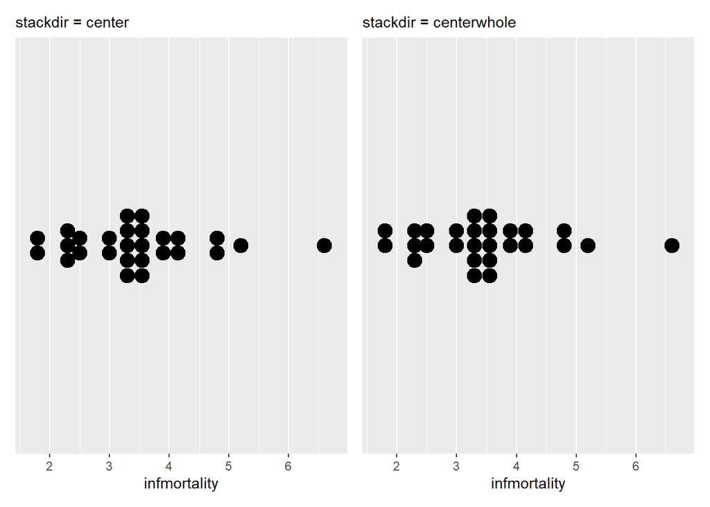

```r
fig_6291 <-
  p + geom_dotplot(binwidth = 0.25, stackdir = "center") +
  scale_y_continuous(breaks = NULL) +
  theme(axis.title.y = element_blank()) +
  labs(subtitle = "stackdir = center")

fig_6292 <-
  p + geom_dotplot(binwidth = 0.25, stackdir = "centerwhole") +
  scale_y_continuous(breaks = NULL) +
  theme(axis.title.y = element_blank()) +
  labs(subtitle = "stackdir = centerwhole")

fig_6291 + fig_6292
```

### 6.11 Making multiple dot plots for grouped data

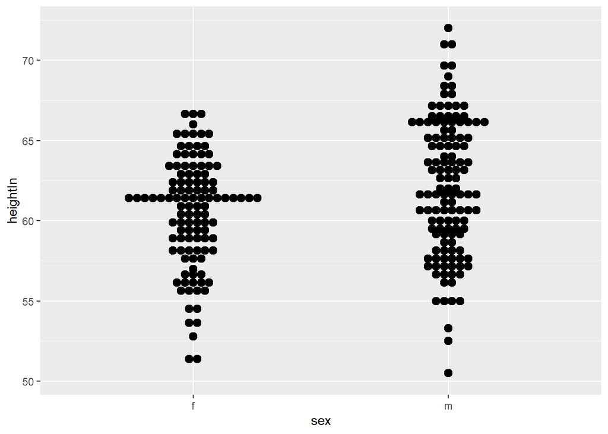

```r
heightweight %>%
  ggplot(aes(x = sex, y = heightIn)) +
  geom_dotplot(binaxis = "y", binwidth = 0.5, stackdir = "center")
```

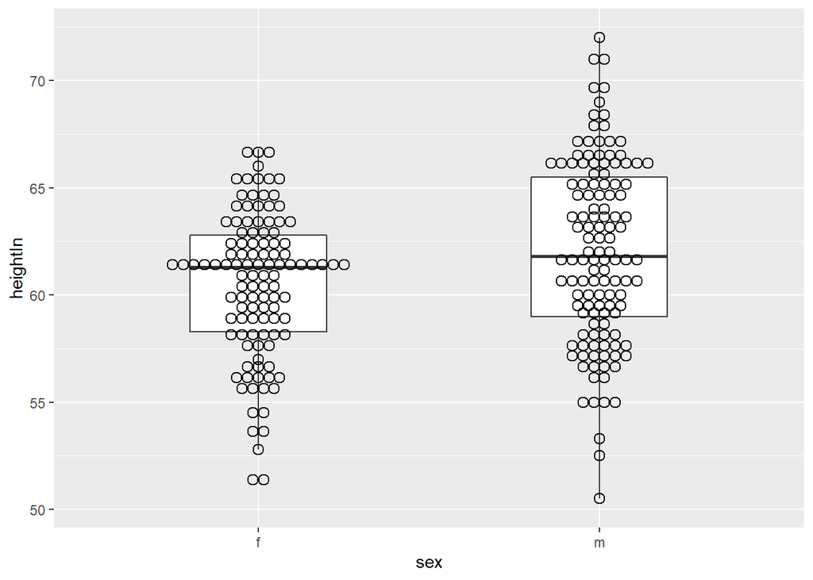

```r
heightweight %>%
  ggplot(aes(x = sex, y = heightIn)) +
  geom_boxplot(outlier.color = NA, width = 0.4) +
  geom_dotplot(binaxis = "y", binwidth = 0.5, stackdir = "center", fill = NA)
```

x값을 numeric으로 사용하기 위해서는 꼭 그룹을 명시해주어야 한다.  
그렇지 않으면 하나의 그룹으로 인식하기 때문이다.  
또한 x축의 tick값은 `scale_x_continous()`로 수정하여 factor levels에 맞게 tick label이 출력되도록 해야 한다.

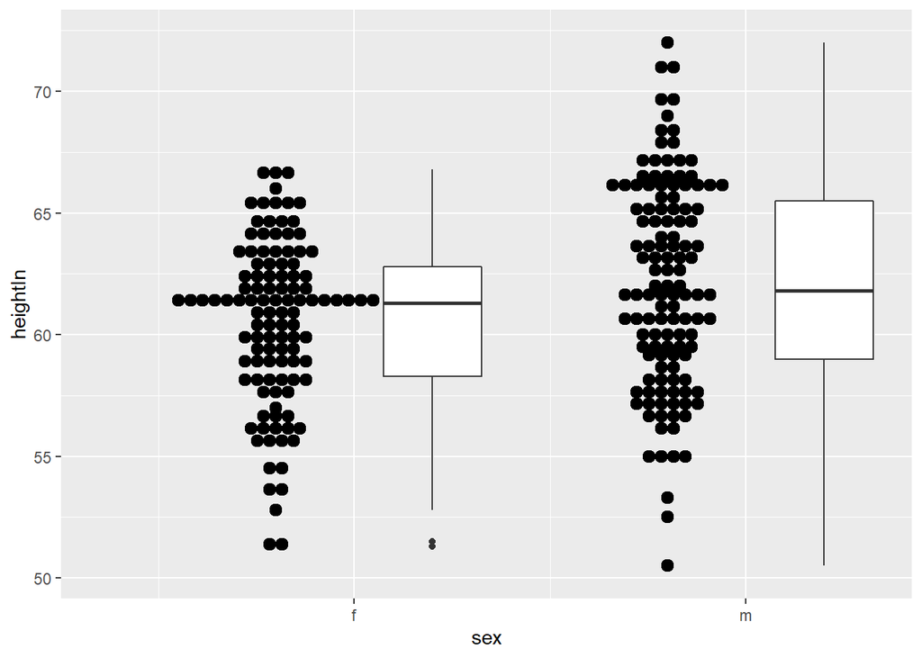

```r
heightweight %>%
  ggplot(aes(x = sex, y = heightIn)) +
  geom_boxplot(aes(x = as.numeric(sex) + 0.2, group = sex), width = 0.25) +
  geom_dotplot(aes(x = as.numeric(sex) - 0.2, group = sex),
               binaxis = "y", binwidth = 0.5, stackdir = "center") +
  scale_x_continuous(breaks = 1:nlevels(heightweight$sex),
                     labels = levels(heightweight$sex))
```

### 6.12 Making a density plot of two-dimensional data

`stat_density2d()`를 사용하여 2D kernel density estimate을 만들 수 있다.  
먼저 데이터 포인트에 따라 density contour를 그린다.  
level에 따른 contour 색을 주고 싶다면 `stat_density2d()`에 `aes(color = ..level..)`을 설정한다.

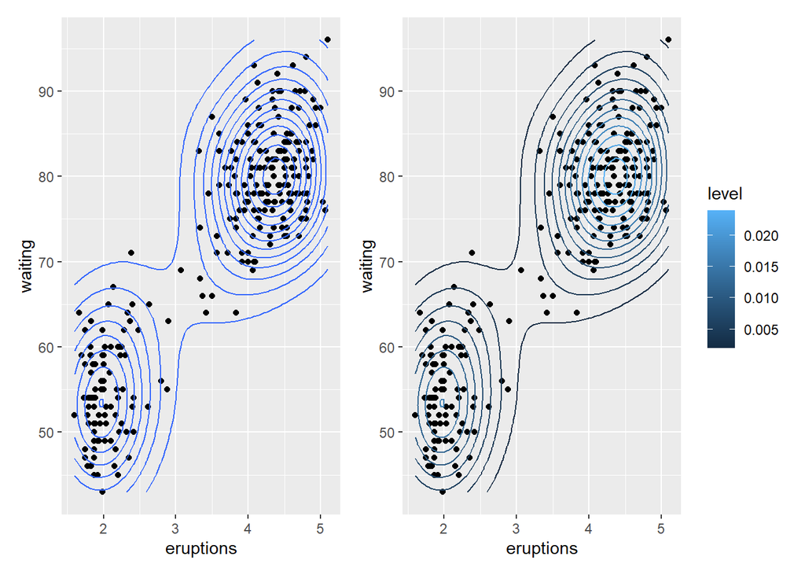

```r
p <- faithful %>% ggplot(aes(x = eruptions, y = waiting))

fig_6331 <-
  p +
  geom_point() +
  stat_density2d()

fig_6332 <-
  p +
  geom_point() +
  stat_density2d(aes(color = ..level..))

fig_6331 + fig_6332
```

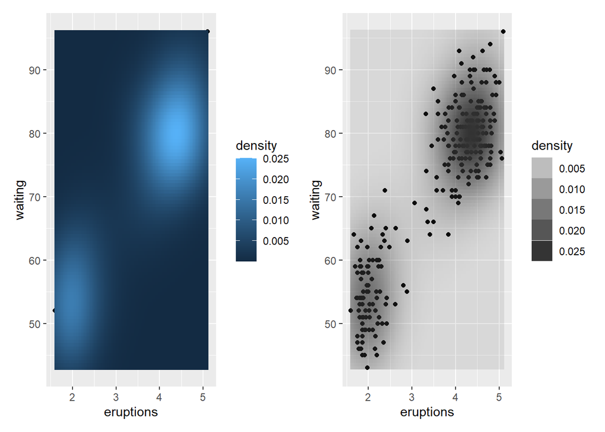

```r
p <- faithful %>% ggplot(aes(x = eruptions, y = waiting))

fig_6341 <-
  p +
  geom_point() +
  stat_density2d(aes(fill = ..density..), geom = "raster", contour = FALSE)

fig_6342 <-
  p +
  geom_point() +
  stat_density2d(aes(alpha = ..density..), geom = "tile", contour = FALSE)

fig_6341 + fig_6342
```

contour line을 사용하는 것이 default인데, tiles의 투명도나 fill color에 따른 density estimate를 사용하는 것도 가능하다.  
one-dimensional density estimate을 사용할 때는 estimate의 bandwidth를 정의해야 한다.  
x, y bandwidth를 위한 vector는 h에 들어간다. h = c(0.5,5)  
x, y방향으로 작은 bandwidth를 사용하면 좀 더 가깝게 적합될 수 있지만 overfitted될 수도 있다.

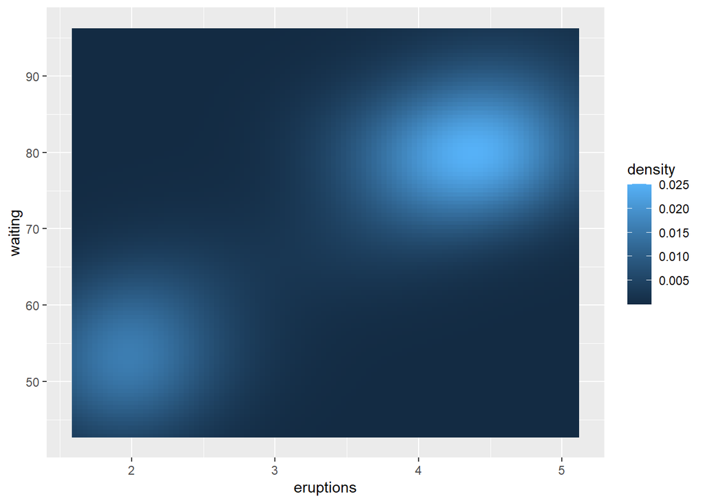

```r
p + stat_density2d(aes(fill = ..density..),
                   geom = "raster", contour = FALSE)
```

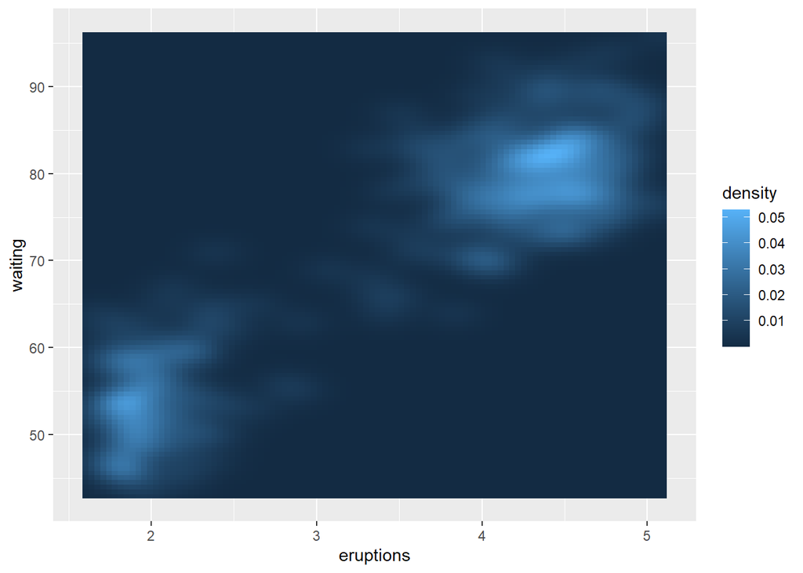

```r
p + stat_density2d(aes(fill = ..density..),
                   geom = "raster", contour = FALSE,
                   h = c(0.5,5))
```

**END**